# First things first

Click **File -> Save a copy in Drive** and click **Open in new tab** in the pop-up window to save your progress in Google Drive.

# Gaussian processes and Bayesian optimization

In this assignment you will learn how to use [GPy](http://sheffieldml.github.io/GPy/) and [GPyOpt](http://sheffieldml.github.io/GPyOpt/) libraries to deal with gaussian processes. These libraries provide quite simple and inuitive interfaces for training and inference, and we will try to get familiar with them in a few tasks.

### Setup

Load auxiliary files and then install and import the necessary libraries.

```python
try:
    import google.colab
    IN_COLAB = True
except:
    IN_COLAB = False
if IN_COLAB:
    print("Downloading Colab files")
    ! shred -u setup_google_colab.py
    ! wget https://raw.githubusercontent.com/hse-aml/bayesian-methods-for-ml/master/setup_google_colab.py -O setup_google_colab.py
    import setup_google_colab
    setup_google_colab.load_data_week6()
```

[output not shown]

```python
! pip install GPy gpyopt xgboost
```

```
     |████████████████████████████████| 962kB 25.5MB/s
     |████████████████████████████████| 61kB 5.8MB/s
     |████████████████████████████████| 71kB 7.7MB/s
```

```python
import numpy as np
import GPy
import GPyOpt
import matplotlib.pyplot as plt
from sklearn.svm import SVR
import sklearn.datasets
from xgboost import XGBRegressor
from sklearn.model_selection import cross_val_score
import time
from w6_grader import GPGrader
%matplotlib inline
```

### Grading

We will create a grader instace below and use it to collect your answers. Note that these outputs will be stored locally inside grader and will be uploaded to platform only after running submiting function in the last part of this assignment. If you want to make partial submission, you can run that cell any time you want.

```python
grader = GPGrader()
```

## Gaussian processes: GPy ([documentation](http://pythonhosted.org/GPy/))

We will start with a simple regression problem, for which we will try to fit a Gaussian Process with RBF kernel.

```python
def generate_points(n=25, noise_variance=0.0036):
    np.random.seed(777)
    X = np.random.uniform(-3., 3., (n, 1))
    y = np.sin(X) + np.random.randn(n, 1) * noise_variance**0.5
    return X, y

def generate_noise(n=25, noise_variance=0.0036):
    np.random.seed(777)
    X = np.random.uniform(-3., 3., (n, 1))
    y = np.random.randn(n, 1) * noise_variance**0.5
    return X, y
```

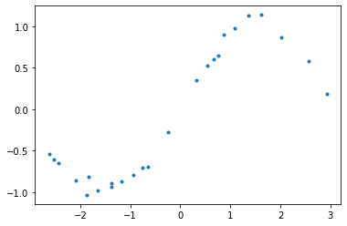

```python
# Create data points
X, y = generate_points()
plt.plot(X, y, '.')
plt.show()
```

To fit a Gaussian Process, you will need to define a kernel. For Gaussian (GBF) kernel you can use `GPy.kern.RBF` function.

**Task 1.1:** Create RBF kernel with variance 1.5 and length-scale parameter 2 for 1D samples and compute value of the kernel between points `X[5]` and `X[9]`. Submit a single number.  
**Hint:** use `.K` property of kernel object.

```python
kernel = GPy.kern.RBF(1, variance=1.5,lengthscale=2)### YOUR CODE HERE
p1 = X[5]
p1 = p1[:,None]
p2 = X[9]
p2 = p2[:,None]
kernel_59 = kernel.K(p1,p2)
grader.submit_GPy_1(kernel_59)
grader.submit_GPy_1(kernel_59)
```

```
Current answer for task 1.1 is: 1.0461813545396959
Current answer for task 1.1 is: 1.0461813545396959
```

**Task 1.2:** Fit GP into generated data. Use kernel from previous task. Submit predicted mean and vairance at position $x=1$.  
**Hint:** use `GPy.models.GPRegression` class.

```python
model = GPy.models.GPRegression(X,y,kernel)### YOUR CODE HERE

p1 = np.array([1.0])
p1 = p1[None,:]
Yp, Vp = model.predict(p1)

mean =Yp[0][0]
variance = Vp[0][0]
grader.submit_GPy_2(mean, variance)
```

```
Current answer for task 1.2 (mean) is: 0.6646774926102937
Current answer for task 1.2 (variance) is: 1.1001478223790582
```

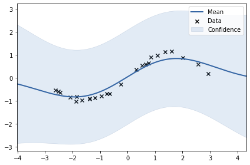

```python
model.plot()
plt.show()
```

We see that the model didn't fit the data quite well. Let's try to fit kernel and noise parameters automatically as discussed in the lecture! You can see the current parameters below:

```python
model
```

**Model**: GP regression  
**Objective**: 27.86687636693494  
**Number of Parameters**: 3  
**Number of Optimization Parameters**: 3  
**Updates**: True

| **GP_regression.** | **value** | **constraints** | **priors** |
| --- | --- | --- | --- |
| rbf.variance | 1.5 | +ve |  |
| rbf.lengthscale | 2.0 | +ve |  |
| Gaussian_noise.variance | 1.0 | +ve |  |

**Task 1.3:** Optimize length-scale, variance and noise component of the model and submit optimal length-scale value of the kernel.  
**Hint:** Use `.optimize()` function of the model and `.lengthscale` property of the kernel.

```
Current answer for task 1.3 is: 1.6252683490431694
```

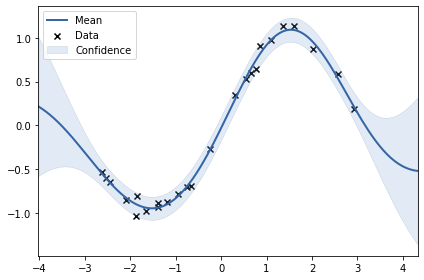

```python
kernel = GPy.kern.RBF(1)
model = GPy.models.GPRegression(X,y,kernel)### YOUR CODE HERE

model.randomize()
model.optimize()
model.plot()

lengthscale = kernel.lengthscale
grader.submit_GPy_3(lengthscale)
```

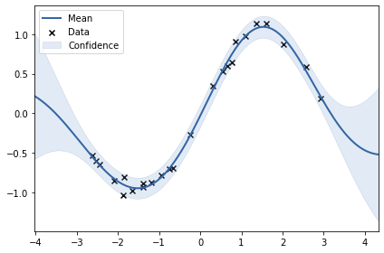

```python
model.plot()
plt.show()
```

As you see, the process generates outputs just right. Let's see if GP can figure out itself when we try to fit it into noise or signal.

**Task 1.4:** Generate two datasets: sinusoid wihout noise and samples from gaussian noise. Optimize kernel parameters and submit optimal values of noise component.  
**Note:** generate data only using `generate_points(n, noise_variance)` and `generate_noise(n, noise_variance)` function!

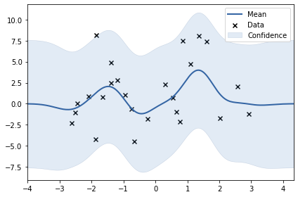

```python
X, y = generate_noise(noise_variance=10)
kernel = GPy.kern.RBF(1)
model = GPy.models.GPRegression(X,y,kernel)### YOUR CODE HERE

model.randomize()
model.optimize()
model.plot()

noise = model.Gaussian_noise[0]
```

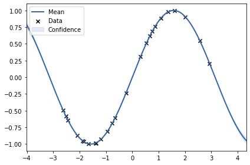

```python
X, y = generate_points(noise_variance=0)
kernel = GPy.kern.RBF(1)
model = GPy.models.GPRegression(X,y,kernel)### YOUR CODE HERE

model.randomize()
model.optimize()
model.plot()

just_signal = model.Gaussian_noise[0]
```

```python
grader.submit_GPy_4(noise, just_signal)
```

```
Current answer for task 1.4 (noise) is: 10.143386946892639
Current answer for task 1.4 (just signal) is: 6.341227731767872e-14
```

## Sparse GP

For the sparse model with inducing points, you should use `GPy.models.SparseGPRegression` class. You can set the number of inducing inputs with parameter `num_inducing` and optimize their positions and values with `.optimize()` call.

**Task 1.5**: Create a dataset of 1000 points and fit GPRegression. Measure time for predicting mean and variance at position $x=1$. Then fit `SparseGPRegression` with 10 inducing inputs and repeat the experiment. Report speedup as a ratio between consumed time without and with inducing inputs.

```python
X, y = generate_points(1000)
```

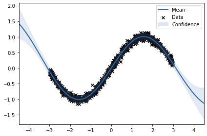

```python
start = time.time()
model = GPy.models.GPRegression(X,y,kernel)### YOUR CODE HERE

model.randomize()
model.optimize()
model.plot()

p1 = np.array([1])
p1 = p1[:,None]
Yp, Vp = model.predict(p1)

mean =Yp### YOUR CODE HERE
variance = Vp
time_gp = time.time()-start
```

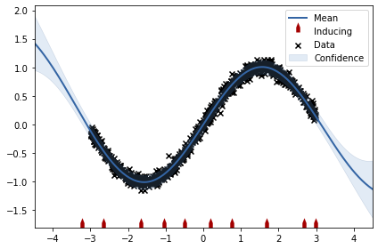

```python
start = time.time()
model = GPy.models.SparseGPRegression(X,y,kernel)### YOUR CODE HERE

model.randomize()
model.optimize()
model.plot()

p1 = np.array([1])
p1 = p1[:,None]
Yp, Vp = model.predict(p1)

mean =Yp### YOUR CODE HERE
variance = Vp
time_sgp = time.time()-start
```

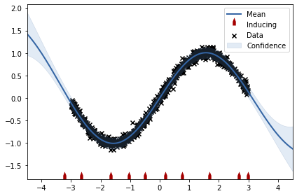

```python
model.plot()
plt.show()
```

```python
grader.submit_GPy_5(time_gp / time_sgp)
```

```
Current answer for task 1.5 is: 6.515420787800301
```

## Bayesian optimization: GPyOpt ([documentation](http://pythonhosted.org/GPyOpt/), [tutorials](http://nbviewer.jupyter.org/github/SheffieldML/GPyOpt/blob/master/manual/index.ipynb))

In this part of the assignment, we will try to find optimal hyperparameters to XGBoost model! We will use data from a small competition to speed things up, but keep in mind that the approach works even for large datasets.

We will use diabetes dataset provided in sklearn package.

```python
dataset = sklearn.datasets.load_diabetes()
X = dataset['data']
y = dataset['target']
```

```python
# Score. Optimizer will try to find minimum, so we will add a "-" sign.
def f(parameters):
    parameters = parameters[0]
    score = -cross_val_score(
        XGBRegressor(learning_rate=parameters[0],
                     max_depth=int(parameters[2]),
                     n_estimators=int(parameters[3]),
                     gamma=int(parameters[1]),
                     min_child_weight = parameters[4]),
        X, y, scoring='neg_mean_squared_error'
    ).mean()
    score = np.array(score)
    return score
```

```python
baseline = -cross_val_score(
    XGBRegressor(), X, y, scoring='neg_mean_squared_error'
).mean()
baseline
```

[output not shown]

```
3437.074407214106
```

```python
# Bounds (NOTE: define continuous variables first, then discrete!)
bounds = [
    {'name': 'learning_rate',
     'type': 'continuous',
     'domain': (0, 1)},

    {'name': 'gamma',
     'type': 'continuous',
     'domain': (0, 5)},

    {'name': 'max_depth',
     'type': 'discrete',
     'domain': (1, 50)},

    {'name': 'n_estimators',
     'type': 'discrete',
     'domain': (1, 300)},

    {'name': 'min_child_weight',
     'type': 'discrete',
     'domain': (1, 10)}
]
```

```python
np.random.seed(777)
optimizer = GPyOpt.methods.BayesianOptimization(
    f=f, domain=bounds,
    acquisition_type ='MPI',
    acquisition_par = 0.1,
    exact_eval=True
)
```

[output not shown]

```python
max_iter = 50
max_time = 60
optimizer.run_optimization(max_iter, max_time)
```

[output not shown]

[output cut: 195 more lines]

[output not shown]

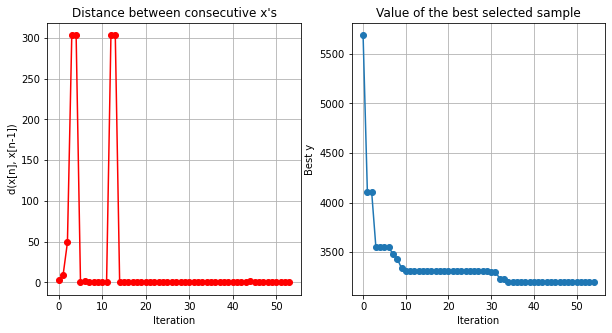

```python
optimizer.plot_convergence()
```

Best values of parameters:

```python
optimizer.X[np.argmin(optimizer.Y)]
```

```
array([3.54564002e-02, 1.39689749e+00, 1.00000000e+00, 3.00000000e+02,
       1.00000000e+00])
```

```python
print('MSE:', np.min(optimizer.Y),
      'Gain:', baseline/np.min(optimizer.Y)*100)
```

```
MSE: 3194.559855787982 Gain: 107.5914855997057
```

**Task 2.1:** Tune SVR model. Find optimal values for three parameters: `C`, `epsilon` and `gamma`. Use range (1e-5, 1000) for `C`, (1e-5, 10) for `epsilon` and `gamma`. Use MPI as an acquisition function with weight 0.1. Submit the optimal value of epsilon that was found by a model.

```python
# Score. Optimizer will try to find minimum, so we will add a "-" sign.
def f(parameters):
    parameters = parameters[0]
    score = -cross_val_score(
        SVR(gamma=parameters[0],
                     epsilon=parameters[1],
                     C=parameters[2]),
        X, y, scoring='neg_mean_squared_error'
    ).mean()
    score = np.array(score)
    return score
```

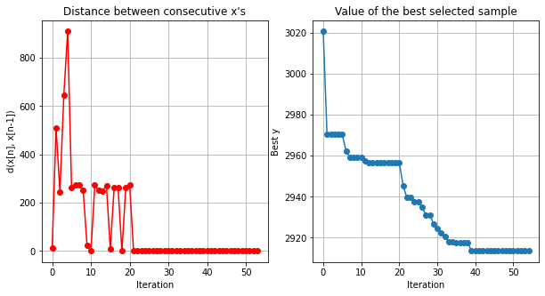

```
Current answer for task 2.1 is: 1.8441708928686518
```

```python
# Bounds (NOTE: define continuous variables first, then discrete!)
bounds = [
    {'name': 'gamma',
     'type': 'continuous',
     'domain': (1e-5, 10)},

    {'name': 'epsilon',
     'type': 'continuous',
     'domain': (1e-5, 10)},

    {'name': 'C',
     'type': 'continuous',
     'domain': (1e-5, 1000)}
]

np.random.seed(777)
optimizer = GPyOpt.methods.BayesianOptimization(
    f=f, domain=bounds,
    acquisition_type ='MPI',
    acquisition_par = 0.1,
    exact_eval=True
)
max_iter = 50
max_time = 60
optimizer.run_optimization(max_iter, max_time)
optimizer.plot_convergence()
best_epsilon = optimizer.X[np.argmin(optimizer.Y)][1]### YOUR CODE HERE
grader.submit_GPyOpt_1(best_epsilon)
```

**Task 2.2:** For the model above submit boost in improvement that you got after tuning hyperparameters (output percents) [e.g. if baseline MSE was 40 and you got 20, output number 200]

```python
baseline = -cross_val_score(
    SVR(), X, y, scoring='neg_mean_squared_error'
).mean()
performance_boost = baseline/np.min(optimizer.Y)### YOUR CODE HERE
grader.submit_GPyOpt_2(performance_boost*100)
```

```
Current answer for task 2.2 is: 170.81296314107138
```

# Authorization & Submission

To submit assignment parts to Cousera platform, please, enter your e-mail and token into variables below. You can generate a token on this programming assignment's page. **Note:** The token expires 30 minutes after generation.

```python
STUDENT_EMAIL ='anand.ba06@reva.edu.in' # EMAIL HERE
STUDENT_TOKEN = 'Pe8bJQEH7GJlUKq6'# TOKEN HERE
grader.status()
```

```
You want to submit these numbers:
Task 1.1: 1.0461813545396959
Task 1.2 (mean): 0.6646774926102937
Task 1.2 (variance): 1.1001478223790582
Task 1.3: 1.6252683490431694
Task 1.4 (noise): 10.143386946892639
Task 1.4 (just signal): 6.341227731767872e-14
Task 1.5: 6.515420787800301
Task 2.1: 1.8441708928686518
Task 2.2: 170.81296314107138
```

If you want to submit these answers, run cell below

```python
grader.submit(STUDENT_EMAIL, STUDENT_TOKEN)
```

```
Submitted to Coursera platform. See results on assignment page!
```